# Week 3: Regularization — Ridge, Lasso, Elastic Net

Stat 577 — Statistical Learning Theory

Soumojit Das

Spring 2026

# Why Regularize?

## When OLS Breaks Down

Last week we established that OLS is **BLUE** — Best Linear Unbiased Estimator.

**But OLS fails spectacularly in several settings:**

**High Dimensions ($p \geq n$)**

- $\mathbf{X}^T\mathbf{X}$ is singular
- Infinitely many solutions
- Perfect training fit, terrible predictions

**Multicollinearity**

- $\mathbf{X}^T\mathbf{X}$ nearly singular
- Huge variance in $\hat{\boldsymbol{\beta}}$
- Unstable estimates

**Overfitting**

- Model memorizes noise
- Low training error, high test error
- Poor generalization

**The Core Problem**

OLS is **unbiased** but can have **enormous variance**. Sometimes we want to trade a little bias for much lower variance.

## Stein’s Phenomenon

**Stein’s Paradox (1956)**

For $p \geq 3$, the MLE (sample mean) is **inadmissible** for estimating a multivariate normal mean under squared error loss.

There exist **biased** estimators that dominate it uniformly!

**Setup:** Observe $\mathbf{z} \sim N(\boldsymbol{\theta}, \sigma^2 \mathbf{I}_p)$. Want to estimate $\boldsymbol{\theta}$.

- MLE: $\hat{\boldsymbol{\theta}}_{MLE} = \mathbf{z}$
- MSE: $E[\|\hat{\boldsymbol{\theta}}_{MLE} - \boldsymbol{\theta}\|^2] = p\sigma^2$

**The James-Stein Estimator**

$$\hat{\boldsymbol{\theta}}_{JS} = \left(1 - \frac{(p-2)\sigma^2}{\|\mathbf{z}\|^2}\right)\mathbf{z}$$

This **shrinks** $\mathbf{z}$ toward the origin. For $p \geq 3$:

$$E[\|\hat{\boldsymbol{\theta}}_{JS} - \boldsymbol{\theta}\|^2] < E[\|\hat{\boldsymbol{\theta}}_{MLE} - \boldsymbol{\theta}\|^2]$$

for **all** $\boldsymbol{\theta}$!

**Key insight:** Shrinkage toward a target (here, zero) can uniformly reduce MSE. This is the foundation of regularization.

## James-Stein Simulation

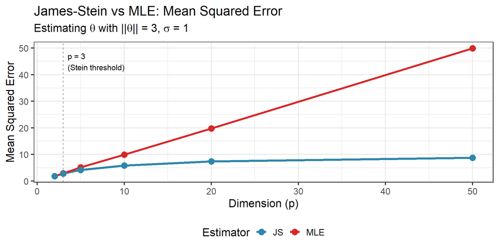

**Observation**

For $p \geq 3$, James-Stein uniformly dominates MLE. The improvement grows with dimension!

## From Stein to Hierarchical Bayes

The James-Stein estimator seemed like a “trick” — why does shrinking toward an arbitrary point help?

**Efron & Morris (1973, 1975)** provided the answer: JS is an **empirical Bayes** estimator!

**The Bayesian Explanation**

Consider the hierarchical model:
$$\theta_j \stackrel{iid}{\sim} N(\mu, A) \quad \text{(prior)}$$
$$z_j | \theta_j \sim N(\theta_j, \sigma^2) \quad \text{(likelihood)}$$

The **posterior mean** (optimal under squared error loss):
$$E[\theta_j | z_j] = \left(1 - \frac{\sigma^2}{\sigma^2 + A}\right)z_j + \frac{\sigma^2}{\sigma^2 + A}\mu$$

**James-Stein emerges** when we:

1. Set $\mu = 0$ (shrink toward origin)
2. Estimate $A$ from the data (empirical Bayes)

**Why This Matters**

- Shrinkage is not a “trick” — it’s **borrowing strength** across parameters
- Each $\theta_j$ estimate is improved by information from *other* $\theta_k$’s
- This is the foundation of **hierarchical Bayes** and modern shrinkage priors
- Ridge, Lasso, and Elastic Net are all doing this same borrowing!

**Historical Arc of Shrinkage**

James-Stein (1961) → Ridge (Hoerl & Kennard, 1970) → Lasso (Tibshirani, 1996) → Elastic Net (Zou & Hastie, 2005)

Each method built on its predecessor, progressing from theoretical insight to practical methodology.

# Norms and Geometry

## $\ell_p$ Norms

The **$\ell_p$ norm** of a vector $\mathbf{x} \in \mathbb{R}^d$:

$$\|\mathbf{x}\|_p = \left(\sum_{i=1}^d |x_i|^p\right)^{1/p}$$

**Common norms:**

| Norm | Formula | Name |
| --- | --- | --- |
| $\ell_1$ | $\sum_i \|x_i\|$ | Manhattan / Taxicab |
| $\ell_2$ | $\sqrt{\sum_i x_i^2}$ | Euclidean |
| $\ell_\infty$ | $\max_i \|x_i\|$ | Maximum / Chebyshev |

**Properties:**

- $\ell_2$ is rotation invariant
- $\ell_1$ promotes sparsity
- $\ell_\infty$ penalizes largest component
- As $p \to 0^+$, approaches $\ell_0$ “norm”

## Unit Balls in Different Norms

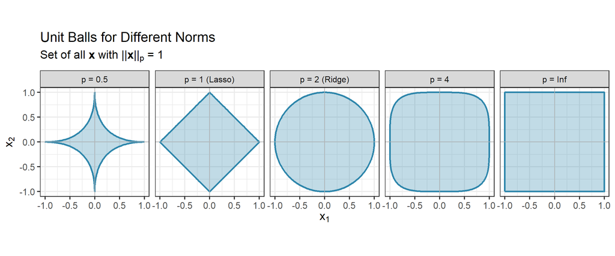

**Key Observation**

The $\ell_1$ ball has **corners** on the axes — this is why Lasso produces sparse solutions!

## The $\ell_0$ “Norm”

The **$\ell_0$ “norm”** counts nonzero entries:

$$\|\mathbf{x}\|_0 = \sum_{i=1}^d \mathbf{1}(x_i \neq 0) = \#\{i : x_i \neq 0\}$$

**Not Actually a Norm!**

A **norm** must satisfy three properties:

1. **Non-negativity:** $\|\mathbf{x}\| \geq 0$ with equality iff $\mathbf{x} = \mathbf{0}$
2. **Homogeneity:** $\|c\mathbf{x}\| = |c| \cdot \|\mathbf{x}\|$ for all scalars $c$
3. **Triangle inequality:** $\|\mathbf{x} + \mathbf{y}\| \leq \|\mathbf{x}\| + \|\mathbf{y}\|$

$\ell_0$ **fails homogeneity**: $\|c\mathbf{x}\|_0 = \|\mathbf{x}\|_0$ for $c \neq 0$, but we need $|c| \cdot \|\mathbf{x}\|_0$.

*Example:* $\|(2, 0, 3)\|_0 = 2$, but $\|2 \cdot (2, 0, 3)\|_0 = \|(4, 0, 6)\|_0 = 2 \neq 2 \cdot 2 = 4$.

**Why $\ell_0$ matters:**

- Directly measures sparsity
- Best subset selection minimizes RSS subject to $\|\boldsymbol{\beta}\|_0 \leq k$
- **Problem:** Combinatorial optimization (NP-hard)

**The Key Insight**

$\ell_1$ is the **tightest convex relaxation** of $\ell_0$.

This makes Lasso computationally tractable while still promoting sparsity!

# Ridge Regression

## Ridge Objective

**Ridge Regression**

**Penalized form:**
$$\hat{\boldsymbol{\beta}}_R = \arg\min_{\boldsymbol{\beta}} \left\{ \sum_{i=1}^n (y_i - \mathbf{x}_i^T\boldsymbol{\beta})^2 + \lambda \sum_{j=1}^p \beta_j^2 \right\}$$

**Constrained form (equivalent):**
$$\hat{\boldsymbol{\beta}}_R = \arg\min_{\boldsymbol{\beta}} \sum_{i=1}^n (y_i - \mathbf{x}_i^T\boldsymbol{\beta})^2 \quad \text{subject to} \quad \sum_{j=1}^p \beta_j^2 \leq t$$

- $\lambda \geq 0$ is the **regularization parameter** (tuning parameter)
- $\lambda = 0$: OLS
- $\lambda \to \infty$: $\hat{\boldsymbol{\beta}}_R \to \mathbf{0}$
- The penalty does **not** include the intercept $\beta_0$

## Deriving the Ridge Solution

**Objective:** Minimize $L(\boldsymbol{\beta}) = (\mathbf{y} - \mathbf{X}\boldsymbol{\beta})^T(\mathbf{y} - \mathbf{X}\boldsymbol{\beta}) + \lambda \boldsymbol{\beta}^T\boldsymbol{\beta}$

Expanding:
$$L(\boldsymbol{\beta}) = \mathbf{y}^T\mathbf{y} - 2\boldsymbol{\beta}^T\mathbf{X}^T\mathbf{y} + \boldsymbol{\beta}^T\mathbf{X}^T\mathbf{X}\boldsymbol{\beta} + \lambda\boldsymbol{\beta}^T\boldsymbol{\beta}$$

Taking the gradient:
$$\nabla_{\boldsymbol{\beta}} L = -2\mathbf{X}^T\mathbf{y} + 2\mathbf{X}^T\mathbf{X}\boldsymbol{\beta} + 2\lambda\boldsymbol{\beta}$$

Setting to zero:
$$\mathbf{X}^T\mathbf{X}\boldsymbol{\beta} + \lambda\boldsymbol{\beta} = \mathbf{X}^T\mathbf{y}$$
$$(\mathbf{X}^T\mathbf{X} + \lambda\mathbf{I})\boldsymbol{\beta} = \mathbf{X}^T\mathbf{y}$$

**Ridge Estimator**

$$\hat{\boldsymbol{\beta}}_R = (\mathbf{X}^T\mathbf{X} + \lambda\mathbf{I})^{-1}\mathbf{X}^T\mathbf{y}$$

**Key property:** $\mathbf{X}^T\mathbf{X} + \lambda\mathbf{I}$ is always invertible for $\lambda > 0$, even when $p > n$!

**Numerical Stability**

Adding $\lambda\mathbf{I}$ not only guarantees invertibility but also **improves the condition number** of $\mathbf{X}^T\mathbf{X} + \lambda\mathbf{I}$, leading to more numerically stable solutions.

**Connection to Sufficient Statistics**

The Ridge estimator depends on the data only through $(\mathbf{X}^T\mathbf{X}, \mathbf{X}^T\mathbf{y})$:

$$\hat{\boldsymbol{\beta}}_R = (\mathbf{X}^T\mathbf{X} + \lambda\mathbf{I})^{-1}\mathbf{X}^T\mathbf{y}$$

For the linear model $\mathbf{y} \sim N(\mathbf{X}\boldsymbol{\beta}, \sigma^2\mathbf{I})$:

- $(\mathbf{X}^T\mathbf{X}, \mathbf{X}^T\mathbf{y})$ are **jointly sufficient** for $\boldsymbol{\beta}$ (when $\sigma^2$ known)
- Ridge is a **linear shrinkage** of OLS: $\hat{\boldsymbol{\beta}}_R = \mathbf{W}_\lambda \hat{\boldsymbol{\beta}}_{OLS}$
- where $\mathbf{W}_\lambda = (\mathbf{X}^T\mathbf{X} + \lambda\mathbf{I})^{-1}\mathbf{X}^T\mathbf{X}$

This preserves the **sufficiency principle** — Ridge doesn’t discard information, it just reweights it!

## Bayesian Interpretation

Ridge regression has an elegant **Bayesian interpretation**.

**Likelihood:** $\mathbf{y} | \boldsymbol{\beta} \sim N(\mathbf{X}\boldsymbol{\beta}, \sigma^2\mathbf{I})$

**Prior:** $\boldsymbol{\beta} \sim N(\mathbf{0}, \tau^2\mathbf{I})$ (independent Gaussian prior)

**Posterior mode (MAP estimate):**
$$\hat{\boldsymbol{\beta}}_{MAP} = \arg\max_{\boldsymbol{\beta}} \left\{ \log p(\mathbf{y}|\boldsymbol{\beta}) + \log p(\boldsymbol{\beta}) \right\}$$

$$= \arg\min_{\boldsymbol{\beta}} \left\{ \frac{1}{2\sigma^2}\|\mathbf{y} - \mathbf{X}\boldsymbol{\beta}\|^2 + \frac{1}{2\tau^2}\|\boldsymbol{\beta}\|^2 \right\}$$

**Connection to Ridge**

$$\lambda = \frac{\sigma^2}{\tau^2}$$

- Large $\tau^2$ (diffuse prior) $\Rightarrow$ small $\lambda$ $\Rightarrow$ close to OLS
- Small $\tau^2$ (tight prior) $\Rightarrow$ large $\lambda$ $\Rightarrow$ strong shrinkage

**ML Connection: Weight Decay**

The Ridge penalty $\lambda\|\boldsymbol{\beta}\|_2^2$ is **identical** to “weight decay” in neural network training. When you see `weight_decay=0.01` in PyTorch or TensorFlow optimizers, you’re applying Ridge regularization to the network weights.

## Effective Degrees of Freedom

OLS uses $p$ degrees of freedom (for $p$ predictors, excluding intercept).

**Ridge uses fewer!** The **effective degrees of freedom**:

$$\text{df}(\lambda) = \text{tr}\left[\mathbf{X}(\mathbf{X}^T\mathbf{X} + \lambda\mathbf{I})^{-1}\mathbf{X}^T\right] = \sum_{j=1}^p \frac{d_j^2}{d_j^2 + \lambda}$$

where $d_1, \ldots, d_p$ are the singular values of $\mathbf{X}$.

**Properties**

- When $\lambda = 0$: $\text{df}(\lambda) = p$ (OLS)
- When $\lambda \to \infty$: $\text{df}(\lambda) \to 0$
- $\text{df}(\lambda)$ decreases monotonically in $\lambda$

## Effective Degrees of Freedom vs $\lambda$

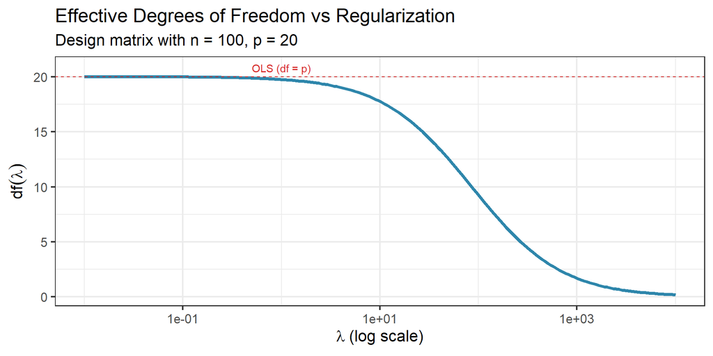

# Ridge via SVD

## The SVD

The **Singular Value Decomposition (SVD)** of $\mathbf{X} \in \mathbb{R}^{n \times p}$:

$$\mathbf{X} = \mathbf{U}\mathbf{D}\mathbf{V}^T$$

where:

- $\mathbf{U} \in \mathbb{R}^{n \times n}$: left singular vectors
  - Columns are orthonormal: $\mathbf{U}^T\mathbf{U} = \mathbf{I}$
  - Span the column space of $\mathbf{X}$
- $\mathbf{V} \in \mathbb{R}^{p \times p}$: right singular vectors
  - Columns are orthonormal: $\mathbf{V}^T\mathbf{V} = \mathbf{I}$
  - Span the row space of $\mathbf{X}$
- $\mathbf{D} \in \mathbb{R}^{n \times p}$: singular values
  - Diagonal matrix with $d_1 \geq d_2 \geq \cdots \geq d_r > 0$
  - $r = \text{rank}(\mathbf{X})$
  - $d_j^2$ are eigenvalues of $\mathbf{X}^T\mathbf{X}$

## OLS Through SVD

Using the SVD, the OLS fitted values:

$$\hat{\mathbf{y}}_{OLS} = \mathbf{X}\hat{\boldsymbol{\beta}}_{OLS} = \mathbf{X}(\mathbf{X}^T\mathbf{X})^{-1}\mathbf{X}^T\mathbf{y}$$

Substituting $\mathbf{X} = \mathbf{U}\mathbf{D}\mathbf{V}^T$:

$$\hat{\mathbf{y}}_{OLS} = \mathbf{U}\mathbf{U}^T\mathbf{y} = \sum_{j=1}^r \mathbf{u}_j \mathbf{u}_j^T \mathbf{y}$$

**Interpretation**

OLS projects $\mathbf{y}$ onto the column space of $\mathbf{X}$, giving **equal weight** to all principal directions.

## Ridge via SVD

The ridge fitted values:

$$\hat{\mathbf{y}}_R = \mathbf{X}(\mathbf{X}^T\mathbf{X} + \lambda\mathbf{I})^{-1}\mathbf{X}^T\mathbf{y}$$

Using SVD of $\mathbf{X} = \mathbf{U}\mathbf{D}\mathbf{V}^T$:

- $\mathbf{X}^T\mathbf{X} = \mathbf{V}\mathbf{D}^2\mathbf{V}^T$
- $(\mathbf{X}^T\mathbf{X} + \lambda\mathbf{I})^{-1} = \mathbf{V}(\mathbf{D}^2 + \lambda\mathbf{I})^{-1}\mathbf{V}^T$

After simplification:

**Ridge via SVD**

$$\hat{\mathbf{y}}_R = \sum_{j=1}^p \mathbf{u}_j \frac{d_j^2}{d_j^2 + \lambda} \mathbf{u}_j^T \mathbf{y}$$

Each principal direction is **shrunk** by the factor $\frac{d_j^2}{d_j^2 + \lambda}$.

**Key insight:**

- Directions with large $d_j$ (high variance): shrinkage factor $\approx 1$ (little shrinkage)
- Directions with small $d_j$ (low variance): shrinkage factor $\approx 0$ (heavy shrinkage)

Ridge **adaptively** shrinks directions based on their variance in the data!

## SVD Shrinkage Factors

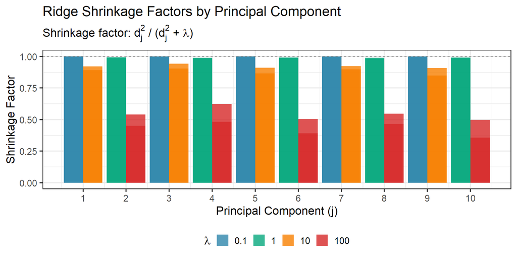

**Common Misconception**

Ridge does **NOT** shrink all coefficients equally. Shrinkage is **adaptive**: directions with less variance (smaller singular values) are shrunk more aggressively.

## Connection to PCA

**Ridge and Principal Components**

Ridge regression shrinks along **principal component directions**:

- **High-variance directions** (large $d_j$): preserved (little shrinkage)
- **Low-variance directions** (small $d_j$): suppressed (heavy shrinkage)

This is similar to **Principal Component Regression (PCR)**, but: - PCR: hard threshold (keep or discard components) - Ridge: soft shrinkage (continuous weighting)

**Why shrink low-variance directions?**

- Low variance in $\mathbf{X}$ $\Rightarrow$ little information about $\boldsymbol{\beta}$
- OLS estimates in these directions are **unstable** (high variance)
- Better to shrink toward zero than estimate poorly

# Lasso Regression

## Lasso Objective

**Lasso (Least Absolute Shrinkage and Selection Operator)**

**Penalized form:**
$$\hat{\boldsymbol{\beta}}_L = \arg\min_{\boldsymbol{\beta}} \left\{ \frac{1}{2n}\sum_{i=1}^n (y_i - \mathbf{x}_i^T\boldsymbol{\beta})^2 + \lambda \sum_{j=1}^p |\beta_j| \right\}$$

**Constrained form:**
$$\hat{\boldsymbol{\beta}}_L = \arg\min_{\boldsymbol{\beta}} \sum_{i=1}^n (y_i - \mathbf{x}_i^T\boldsymbol{\beta})^2 \quad \text{subject to} \quad \sum_{j=1}^p |\beta_j| \leq t$$

**Key differences from Ridge:**

- $\ell_1$ penalty instead of $\ell_2$
- **No closed-form solution** (requires optimization)
- **Produces sparse solutions** (some $\hat{\beta}_j = 0$ exactly)

**Bayesian Interpretation**

Lasso corresponds to a **Laplace (double-exponential) prior**:
$$p(\beta_j) \propto \exp\left(-\frac{|\beta_j|}{\tau}\right)$$

The Laplace distribution has heavier tails than Gaussian and places more mass at zero, promoting sparsity. Compare: Ridge $\leftrightarrow$ Gaussian prior; Lasso $\leftrightarrow$ Laplace prior.

## Soft Thresholding

For **orthogonal design** ($\mathbf{X}^T\mathbf{X} = n\mathbf{I}$), Lasso has a closed form!

The Lasso objective separates by coordinate. Let $z = \hat{\beta}_j^{OLS}$. We solve:
$$\min_{\beta} \left\{ \frac{1}{2}(z - \beta)^2 + \lambda|\beta| \right\}$$

**Derivation via subgradient:**

The subgradient condition for optimality is:
$$0 \in -(z - \beta) + \lambda \cdot \partial|\beta|$$

where $\partial|\beta|$ is the subdifferential of $|\beta|$:
$$\partial|\beta| = \begin{cases} \{1\} & \text{if } \beta > 0 \\ [-1, 1] & \text{if } \beta = 0 \\ \{-1\} & \text{if } \beta < 0 \end{cases}$$

**Case 1:** If $\hat{\beta} = 0$, then $0 \in -z + \lambda[-1, 1]$, which requires $|z| \leq \lambda$.

**Case 2:** If $\hat{\beta} > 0$, then $z - \hat{\beta} = \lambda$, so $\hat{\beta} = z - \lambda$. This is positive when $z > \lambda$.

**Case 3:** If $\hat{\beta} < 0$, then $z - \hat{\beta} = -\lambda$, so $\hat{\beta} = z + \lambda$. This is negative when $z < -\lambda$.

**Soft Thresholding**

$$\hat{\beta}_j^{Lasso} = \text{sign}(\hat{\beta}_j^{OLS})\left(|\hat{\beta}_j^{OLS}| - \lambda\right)_+$$

where $(x)_+ = \max(0, x)$.

**Interpretation:**

- If $|\hat{\beta}_j^{OLS}| \leq \lambda$: shrink to exactly zero (inside “dead zone”)
- If $|\hat{\beta}_j^{OLS}| > \lambda$: shrink by $\lambda$ toward zero

## Soft vs Hard vs Ridge Shrinkage

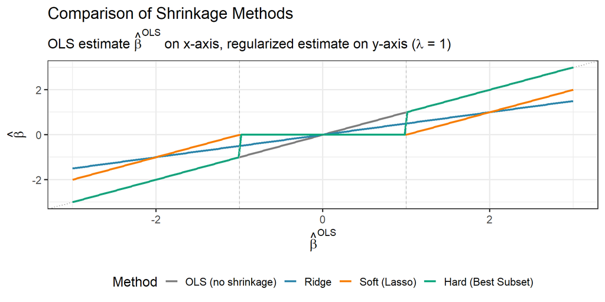

## Why Lasso Gives Sparsity

**Ridge constraint region:**

- The constraint $\sum_j \beta_j^2 \leq t$ defines a **ball**
- RSS contours are ellipses
- Solution typically at a smooth point
- **No exact zeros** (except by chance)

**Lasso constraint region:**

- The constraint $\sum_j |\beta_j| \leq t$ defines a **diamond**
- Diamond has **corners** on coordinate axes
- Solution often at a corner
- **Exact zeros** for some coefficients

## Geometry: Ridge vs Lasso

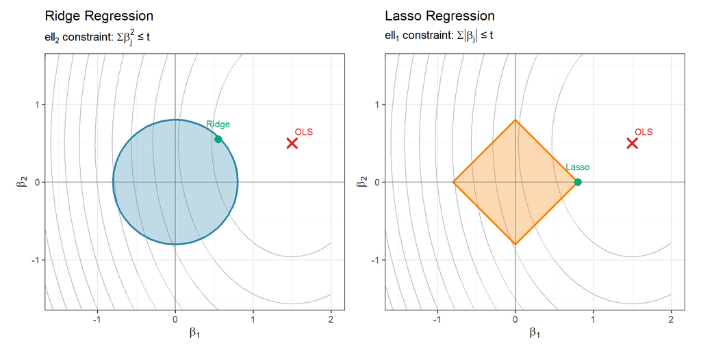

## Subdifferential Perspective

Why does $\ell_1$ allow exact zeros but $\ell_2$ does not?

**For Ridge ($\ell_2$):** The gradient of $|\beta_j|^2$ at $\beta_j = 0$ is $2\beta_j = 0$.

- Zero gradient at zero means no “pull” toward zero
- Must have RSS gradient = 0 at the same point (rare)

**For Lasso ($\ell_1$):** The **subdifferential** of $|\beta_j|$ at $\beta_j = 0$ is $[-1, 1]$.

- Any value in $[-1, 1]$ is a valid “subgradient”
- Optimality condition: $-\frac{\partial RSS}{\partial \beta_j} \in \lambda \cdot [-1, 1]$

**Sparsity Condition**

$\hat{\beta}_j = 0$ whenever $\left|\frac{\partial RSS}{\partial \beta_j}\right| \leq \lambda$

The **interval** of valid subgradients at zero allows the Lasso to “park” coefficients at exactly zero.

**Lasso Selection Caveat**

When predictors are highly correlated, Lasso tends to arbitrarily select one and exclude others. It does **not** always select the “correct” variables. Elastic Net addresses this via the **grouping effect**.

# Elastic Net

## Elastic Net Objective

**Elastic Net (Zou & Hastie, 2005)**

$$\hat{\boldsymbol{\beta}}_{EN} = \arg\min_{\boldsymbol{\beta}} \left\{ \frac{1}{2n}\sum_{i=1}^n (y_i - \mathbf{x}_i^T\boldsymbol{\beta})^2 + \lambda\left[\frac{1-\alpha}{2}\sum_{j=1}^p \beta_j^2 + \alpha\sum_{j=1}^p |\beta_j|\right] \right\}$$

**Parameters:**

- $\lambda \geq 0$: overall regularization strength
- $\alpha \in [0, 1]$: mixing parameter
  - $\alpha = 0$: Ridge
  - $\alpha = 1$: Lasso
  - $0 < \alpha < 1$: Combination

**Intuition**

Elastic Net combines the **variable selection** of Lasso with the **grouped shrinkage** of Ridge.

## The Grouping Effect

**Problem with Lasso:** When predictors are highly correlated, Lasso tends to select only one and ignore the others.

**Elastic Net’s solution:** The Ridge component encourages correlated predictors to be selected together.

**Grouping Effect Theorem (Zou & Hastie)**

For the Elastic Net with $\alpha \in (0, 1)$:

If $\text{Cor}(X_j, X_k) = 1$, then $\hat{\beta}_j = \hat{\beta}_k$.

More generally, if $\rho = \text{Cor}(X_j, X_k)$ is large, then $|\hat{\beta}_j - \hat{\beta}_k|$ is small.

**When to use Elastic Net:**

- Groups of correlated predictors (genomics, imaging)
- Want sparsity but expect related features to enter together
- $p > n$ with correlation structure

## Elastic Net Constraint Shapes

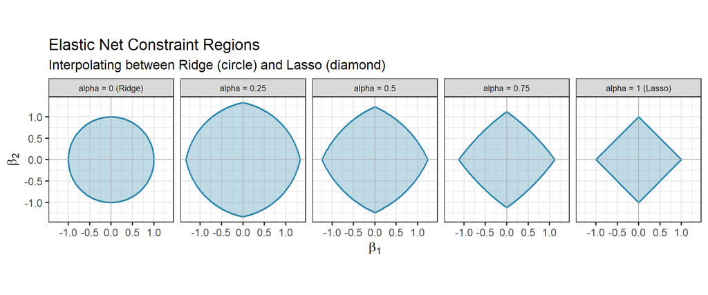

# Selecting $\lambda$

## The Lambda Problem

How do we choose the regularization parameter $\lambda$?

**Small $\lambda$:**

- Less regularization
- Lower bias
- Higher variance
- Risk of overfitting

**Large $\lambda$:**

- More regularization
- Higher bias
- Lower variance
- Risk of underfitting

**The Goal**

Find $\lambda$ that minimizes **expected prediction error** on new data.

We cannot use training error — it always decreases with less regularization!

## K-Fold Cross-Validation

**Procedure:**

1. Divide data into $K$ roughly equal folds
2. For each fold $k = 1, \ldots, K$:
   - Fit model on all data except fold $k$
   - Compute prediction error on fold $k$
3. Average the $K$ error estimates

$$\text{CV}(\lambda) = \frac{1}{K}\sum_{k=1}^K \text{MSE}_k(\lambda)$$

**Choosing $\lambda$:**

**lambda.min:**

$\lambda$ that minimizes CV error

Optimizes prediction accuracy

**lambda.1se:**

Largest $\lambda$ within 1 SE of minimum

More parsimonious model (fewer predictors)

**Other Selection Methods**

**Information criteria** can also select $\lambda$:

- **AIC:** $-2\ell(\hat{\boldsymbol{\beta}}) + 2 \cdot \text{df}(\lambda)$
- **BIC:** $-2\ell(\hat{\boldsymbol{\beta}}) + \log(n) \cdot \text{df}(\lambda)$

BIC penalizes complexity more heavily. We’ll cover these in detail in Week 4.

## CV Error vs $\lambda$

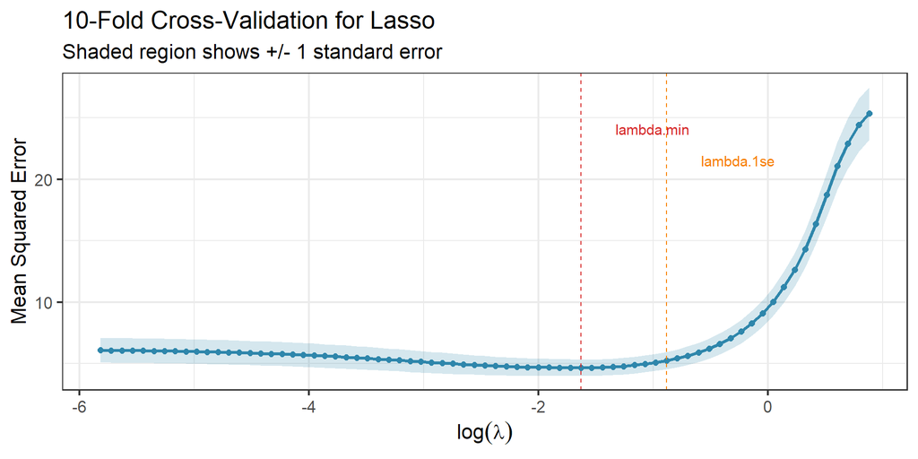

**Package-Specific Lambda Scaling**

Lambda is scaled differently across packages:

- **glmnet (R):** Uses $\alpha\lambda$ formulation; objective includes $\frac{1}{2n}$ factor
- **sklearn (Python):** Different scaling; direct comparison of lambda values is invalid

Always use cross-validation within each package rather than transferring lambda values between R and Python.

# Code Demos: glmnet in Action

## Ridge Coefficient Paths

```r
# Same data as before
set.seed(577)
n <- 200; p <- 50
X <- matrix(rnorm(n * p), n, p)
colnames(X) <- paste0("X", 1:p)
beta_true <- c(rep(2, 5), rep(0, 45))
y <- X %*% beta_true + rnorm(n, 0, 2)

# Fit Ridge
ridge_fit <- glmnet(X, y, alpha = 0)

# Extract coefficient paths
coef_matrix <- as.matrix(ridge_fit$beta)
ridge_data <- as_tibble(t(coef_matrix)) %>%
  mutate(log_lambda = log(ridge_fit$lambda)) %>%
  pivot_longer(-log_lambda, names_to = "variable", values_to = "coefficient") %>%
  mutate(true_nonzero = variable %in% paste0("X", 1:5))

p <- ggplot(ridge_data, aes(x = log_lambda, y = coefficient,
                             group = variable, color = true_nonzero)) +
  geom_line(alpha = 0.7) +
  scale_color_manual(values = c("TRUE" = col_red, "FALSE" = "gray70"),
                     labels = c("TRUE" = "True signal", "FALSE" = "Noise")) +
  labs(title = "Ridge Regression: Coefficient Paths",
       subtitle = "Coefficients shrink smoothly toward zero",
       x = expression(log(lambda)),
       y = "Coefficient Value",
       color = "") +
  theme(legend.position = "bottom")

ggsave(file.path(fig_dir, "09_ridge_path.png"), p, width = 10, height = 5, dpi = 150)
p
```

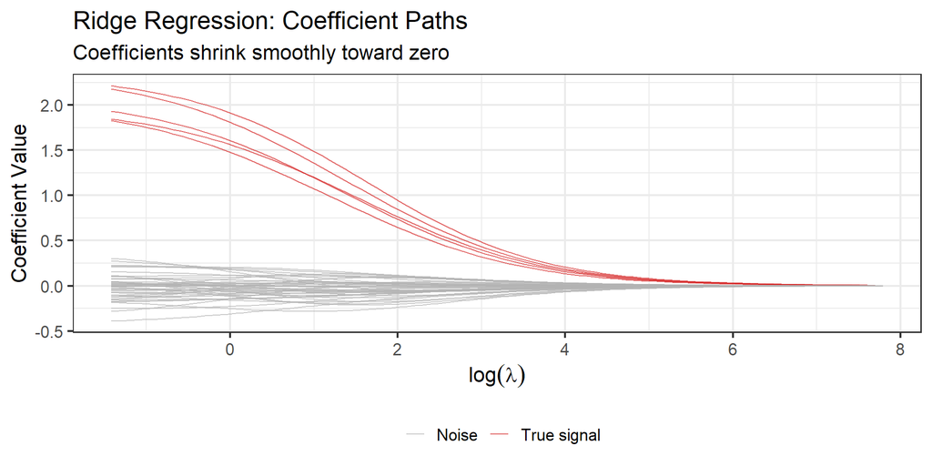

## Lasso Coefficient Paths

```r
# Fit Lasso
lasso_fit <- glmnet(X, y, alpha = 1)

# Extract coefficient paths
coef_matrix <- as.matrix(lasso_fit$beta)
lasso_data <- as_tibble(t(coef_matrix)) %>%
  mutate(log_lambda = log(lasso_fit$lambda)) %>%
  pivot_longer(-log_lambda, names_to = "variable", values_to = "coefficient") %>%
  mutate(true_nonzero = variable %in% paste0("X", 1:5))

p <- ggplot(lasso_data, aes(x = log_lambda, y = coefficient,
                             group = variable, color = true_nonzero)) +
  geom_line(alpha = 0.7) +
  scale_color_manual(values = c("TRUE" = col_red, "FALSE" = "gray70"),
                     labels = c("TRUE" = "True signal", "FALSE" = "Noise")) +
  labs(title = "Lasso Regression: Coefficient Paths",
       subtitle = "Coefficients hit exactly zero (sparsity)",
       x = expression(log(lambda)),
       y = "Coefficient Value",
       color = "") +
  theme(legend.position = "bottom")

ggsave(file.path(fig_dir, "10_lasso_path.png"), p, width = 10, height = 5, dpi = 150)
p
```

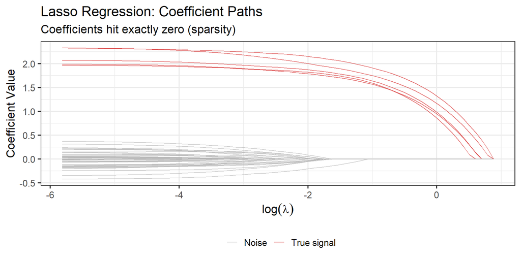

**Python Equivalents**

In **scikit-learn**, use:

- `sklearn.linear_model.Ridge`
- `sklearn.linear_model.Lasso`
- `sklearn.linear_model.ElasticNet`

Note: Lambda scaling differs between packages—always tune via CV within each framework.

## cv.glmnet Output

```r
# Cross-validation for Lasso
cv_lasso <- cv.glmnet(X, y, alpha = 1, nfolds = 10)

# Save the default plot
png(file.path(fig_dir, "11_cv_glmnet.png"), width = 1000, height = 600, res = 100)
plot(cv_lasso)
title("Cross-Validation for Lasso (cv.glmnet)", line = 2.5)
invisible(dev.off())

# Display
plot(cv_lasso)
title("Cross-Validation for Lasso (cv.glmnet)", line = 2.5)
```

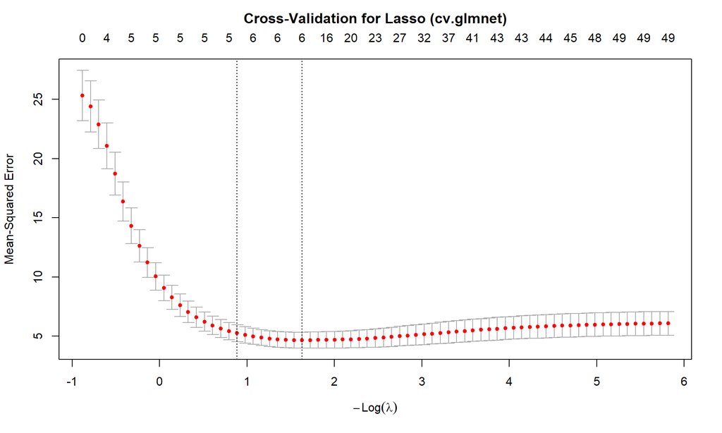

## Ridge vs Lasso: Comparison

```r
# Cross-validation for both
cv_ridge <- cv.glmnet(X, y, alpha = 0, nfolds = 10)
cv_lasso <- cv.glmnet(X, y, alpha = 1, nfolds = 10)

# Combine results
comparison_data <- bind_rows(
  tibble(
    log_lambda = log(cv_ridge$lambda),
    cvm = cv_ridge$cvm,
    cvsd = cv_ridge$cvsd,
    method = "Ridge"
  ),
  tibble(
    log_lambda = log(cv_lasso$lambda),
    cvm = cv_lasso$cvm,
    cvsd = cv_lasso$cvsd,
    method = "Lasso"
  )
)

# Best lambdas
best_lambdas <- tibble(
  method = c("Ridge", "Lasso"),
  log_lambda = c(log(cv_ridge$lambda.min), log(cv_lasso$lambda.min)),
  min_cvm = c(min(cv_ridge$cvm), min(cv_lasso$cvm))
)

p <- ggplot(comparison_data, aes(x = log_lambda, y = cvm, color = method)) +
  geom_ribbon(aes(ymin = cvm - cvsd, ymax = cvm + cvsd, fill = method),
              alpha = 0.2, color = NA) +
  geom_line(linewidth = 1) +
  geom_point(data = best_lambdas, aes(x = log_lambda, y = min_cvm),
             size = 4, shape = 18) +
  scale_color_manual(values = c("Ridge" = col_blue, "Lasso" = col_orange)) +
  scale_fill_manual(values = c("Ridge" = col_blue, "Lasso" = col_orange)) +
  labs(title = "Ridge vs Lasso: Cross-Validation Comparison",
       subtitle = "Diamonds mark lambda.min for each method",
       x = expression(log(lambda)),
       y = "CV Mean Squared Error",
       color = "", fill = "") +
  theme(legend.position = "bottom")

ggsave(file.path(fig_dir, "12_ridge_vs_lasso_comparison.png"), p, width = 12, height = 6, dpi = 150)
p
```

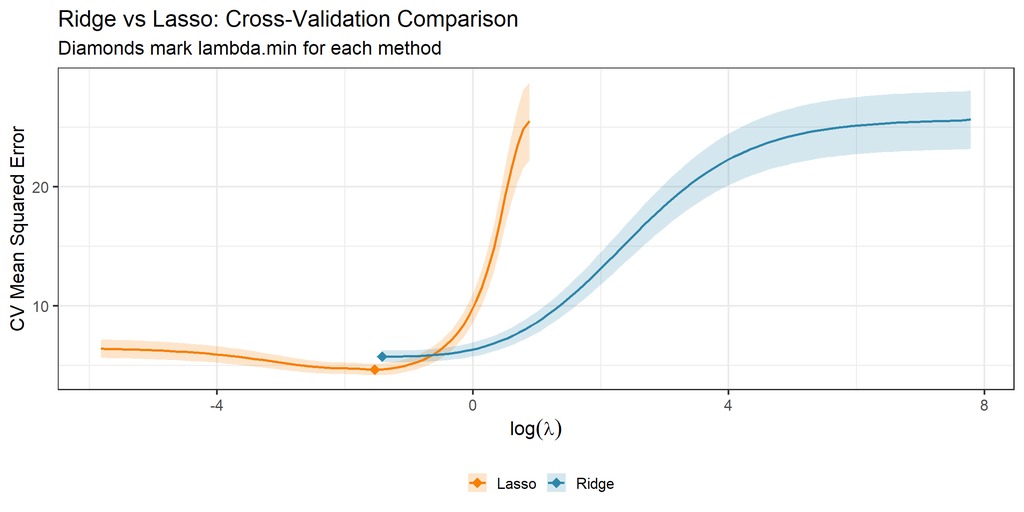

# Summary

## Comparison: Ridge vs Lasso vs Elastic Net

| Property | Ridge | Lasso | Elastic Net |
| --- | --- | --- | --- |
| Penalty | $\lambda\sum_j \beta_j^2$ | $\lambda\sum_j \|\beta_j\|$ | $\lambda[\alpha\sum_j\|\beta_j\| + \frac{1-\alpha}{2}\sum_j\beta_j^2]$ |
| Sparsity | No | Yes | Yes |
| Closed form | Yes | No | No |
| Correlated predictors | Shrinks together | Selects one | Selects groups |
| $p > n$ | Handles well | Selects $\leq n$ | Handles well |
| Bayesian prior | Gaussian | Laplace | Mixture |
| Computation | Direct solve | Coordinate descent | Coordinate descent |

## Key Takeaways

**Remember These Concepts**

1. **Bias-variance tradeoff:** Regularization introduces bias to reduce variance
2. **Ridge:** Shrinks all coefficients; best when all predictors contribute
3. **Lasso:** Produces sparse solutions via $\ell_1$ penalty; performs variable selection
4. **Elastic Net:** Combines both; handles correlated predictors
5. **SVD insight:** Ridge shrinks along principal components adaptively
6. **Cross-validation:** Essential for choosing $\lambda$; use lambda.1se for parsimony

## Looking Ahead

**Next week:** Model Selection and Resampling Methods

**What we covered:**

- Why OLS fails (high dimensions, multicollinearity)
- Ridge: $\ell_2$ penalty, SVD shrinkage
- Lasso: $\ell_1$ penalty, sparsity
- Elastic Net: best of both
- Cross-validation for $\lambda$

**Coming up:**

- K-fold CV in depth
- Bootstrap methods
- Information criteria (AIC, BIC)
- Model selection strategies
- Stability selection

**Preparation**

Review: ESL Chapter 7 (Model Assessment), ISLR Chapter 5 (Resampling Methods)